# Applied Statistics Project

## Submitted by Utathya Ghosh

### Batch - AIML Online Jan 21-A

```python
# Loading the required libraries in one place
import math
import pandas as pd
import numpy as np
import os
from matplotlib import pyplot as plt
import seaborn as sns
sns.set(color_codes=True) # adds a nice background to the graphs
%matplotlib inline
import scipy.stats as stats
import statistics
from scipy.stats import ttest_ind, mannwhitneyu
import datetime as dt
from statsmodels.stats.multicomp import pairwise_tukeyhsd
```

# PART ONE

# QUESTION BASED

# TOTAL SCORE - 15

#### 1.1 Joint Probability = People who planned to purchase and People who actually purchased / Sample Total (Diagonal)

```python
ans = 100/2000
print("1.1 Joint probability is : ", ans, "or %2.0f%%" %(ans*100))
```

```
1.1 Joint probability is :  0.05 or  5%
```

#### 1.2 Joint Probability = People who planned to purchase and People who actually purchased / People planned to Purchase (Marginal)

```python
ans = 100/500
print("Joint probability is : ", ans, "or %2.0f%%" %(ans*100))
```

```
Joint probability is :  0.2 or 20%
```

```python
# Removing Variables
del ans
```

#### 2. Question:

An electrical manufacturing company conducts quality checks at specified periods on the products it manufactures. Historically, the failure rate for the manufactured item is 5%. Suppose a random sample of 10 manufactured items is selected. Answer the following questions.

###### We surmise from the data provided and question posed that a random sample of 10 was taken, the failure rate provided is equal across trials, only a success or failure is possible and the trials are independent (As in result of one event does not influence others) . Hence we can safely assume that the distibution will follow a binomial distribution.

###### So to answer this question first let us visualise and create the required binomial distribution

```python
#sample space
n=10

#Probability of defects or failure rate
p=.05

k=np.arange(0,11)

binomial = stats.binom.pmf(k,n,p)

binomial
```

```
array([5.98736939e-01, 3.15124705e-01, 7.46347985e-02, 1.04750594e-02,
       9.64808106e-04, 6.09352488e-05, 2.67259863e-06, 8.03789063e-08,
       1.58642578e-09, 1.85546875e-11, 9.76562500e-14])
```

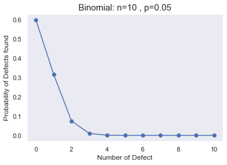

```python
# Plotting the binomial probability distribution

plt.plot(k,binomial,'o-')
plt.title('Binomial: n=%i , p=%.2f' % (n,p), fontsize=15)
plt.xlabel('Number of Defect')
plt.ylabel('Probability of Defects found')
plt.grid()
plt.show()
```

#### A. Probability that none of the items are defective?

###### Based on the chart above and the question posed to us we can see that zero defects is possible only at the first point on the chart hence:-

```python
print("Probability that none of the items are defective is : ", binomial[0], "or %2.4f%%" %(binomial[0]*100))
```

```
Probability that none of the items are defective is :  0.5987369392383789 or 59.8737%
```

#### B. Probability that exactly one of the items is defective?

###### Based on the chart above and the question posed to us we can see that 1 defect is possible only at the second point on the chart hence:-

```python
print("Probability that exactly 1 item is defective is : ",
      binomial[1], "or %2.4f%%" %(binomial[1]*100))
```

```
Probability that exactly 1 item is defective is :  0.31512470486230504 or 31.5125%
```

#### C. Probability that two or fewer of the items are defective?

###### Based on the chart above and the question posed to us we can see that 2 or fewer defects is the summation of all the points on or before the third point

```python
print("Probability that two or fewer of the items are defective is : ",
      sum(binomial[:3]), "or %2.4f%%" %(sum(binomial[:3])*100))
```

```
Probability that two or fewer of the items are defective is :  0.9884964426207035 or 98.8496%
```

#### D. Probability that three or more of the items are defective ?

###### Based on the chart above and the question posed to us we can see that 3 or more defect is the summation of all the points on or after the fourth point

```python
print("Probability that three or more of the items are defective is : ",
      sum(binomial[4:]), "or %2.4f%%" %(sum(binomial[3:])*100))
```

[output not shown]

```python
# Removing Variables
del n, p, k, binomial
```

#### 3. Question:

A car salesman sells on an average 3 cars per week.

A. Probability that in a given week he will sell some cars. B. Probability that in a given week he will sell 2 or more but less than 5 cars. C. Plot the poisson distribution function for cumulative probability of cars sold per-week vs number of cars sold perweek.

###### We surmise from the data provided and question posed that there is no upper limit of cars sold, we have been provided the rate by the question which is a constant and we can assume that the event of selling each car are independent events. Hence we assume that the function follows a poisson distribution.

###### So to answer this question first let us visualise and create the required possion distribution

```python
#average rate of car sold per week, denoted with lambda in the question for poisson distribution

rate = 3

#a numpy array of different no. of successes ranging from 0 to 19 to construct a probability distribution

n=np.arange(0,20)

#calculating the distribution and storing the distribution of probablitites in an array
poisson = stats.poisson.pmf(n,rate)

#printing the probability distribution for different values of x
poisson
```

```
array([4.97870684e-02, 1.49361205e-01, 2.24041808e-01, 2.24041808e-01,
       1.68031356e-01, 1.00818813e-01, 5.04094067e-02, 2.16040315e-02,
       8.10151179e-03, 2.70050393e-03, 8.10151179e-04, 2.20950322e-04,
       5.52375804e-05, 1.27471339e-05, 2.73152870e-06, 5.46305740e-07,
       1.02432326e-07, 1.80762929e-08, 3.01271548e-09, 4.75691918e-10])
```

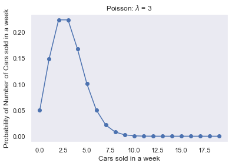

```python
# Plotting the poisson distribution

plt.plot(n,poisson,'o-')
plt.title('Poisson: $\lambda$ = %i ' % rate)
plt.xlabel('Cars sold in a week')
plt.ylabel('Probability of Number of Cars sold in a week')
plt.grid()
plt.show()
```

#### A. Probability that in a given week he will sell some cars.

###### Probability of selling some cars means he will sell 1 or more cars. Hence based on the chart above and the question posed to us we can see that 1 or more cars sold is the summation of all the points on or after the second point

```python
print("Probability that some cars are sold is : ", sum(poisson[1:]), "or %2.4f%%" %(sum(poisson[1:])*100))
```

```
Probability that some cars are sold is :  0.950212931548992 or 95.0213%
```

#### B. Probability that in a given week he will sell 2 or more but less than 5 cars.

###### Based on the chart above and the question posed to us we can see that 2 or more but less than 5 cars sold is the summation of all the points on or after the third point but on or before the fifth point

```python
print("Probability that he will sell 2 or more but less than 5 cars is : ",
      sum(poisson[2:5]), "or %2.4f%%" %(sum(poisson[2:5])*100))
```

```
Probability that he will sell 2 or more but less than 5 cars is :  0.6161149710523164 or 61.6115%
```

#### C. Plot the poisson distribution function for cumulative probability of cars sold per-week vs number of cars sold perweek.

###### To plot the cumulative distribution we must understand how it is different from the chart at the start of the answer. Cumulative probability means the sum of all the values present on the left of the x-axis point. This can be easily constructed through a loop which add all the values which appear on the left in the poisson list.

```python
# Initialising the new list
poisson_cdf = [None]*len(poisson)

# Creating the new variable with cumulative probability distribution
for idx in range(len(poisson)):
    poisson_cdf[idx] = sum(poisson[:idx])
```

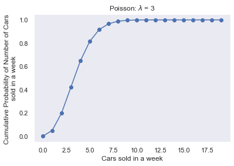

```python
# Plotting the poisson cumulative probability distribution

plt.plot(n,poisson_cdf,'o-')
plt.title('Poisson: $\lambda$ = %i ' % rate)
plt.xlabel('Cars sold in a week')
plt.ylabel('Cumulative Probability of Number of Cars \nsold in a week')
plt.grid()
plt.show()
```

```python
# Removing Variables
del rate, n, poisson, poisson_cdf, idx
```

#### 4. Question:

Accuracy in understanding orders for a speech based bot at a restaurant is important for the Company X which has designed, marketed and launched the product for a contactless delivery due to the COVID-19 pandemic. Recognition accuracy that measures the percentage of orders that are taken correctly is 86.8%. Suppose that you place order with the bot and two friends of yours independently place orders with the same bot. Answer the following questions. A. What is the probability that all three orders will be recognised correctly? B. What is the probability that none of the three orders will be recognised correctly? C. What is the probability that at least two of the three orders will be recognised correctly?

###### We surmise from the data provided and question posed that a random sample of 3 (My two friends and I) was taken, the success rate provided is equal across trials, only a success or failure is possible and that my friend and that we conducted independent trials. Hence we can safely assume that the distibution will follow a binomial distribution.

###### So to answer this question first let us visualise and create the required binomial distribution

```python
#sample space
n=3

# Probability of success
p=.868

k=np.arange(0,4)

binomial = stats.binom.pmf(k,n,p)

binomial
```

```
array([0.00229997, 0.0453721 , 0.2983559 , 0.65397203])
```

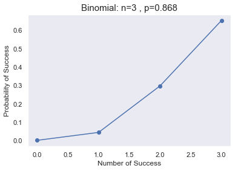

```python
# Plotting the binomial probability distribution

plt.plot(k,binomial,'o-')
plt.title('Binomial: n=%i , p=%.3f' % (n,p), fontsize=15)
plt.xlabel('Number of Success')
plt.ylabel('Probability of Success')
plt.grid()
plt.show()
```

#### A. What is the probability that all three orders will be recognised correctly?

###### Based on the chart above and the question posed to us we can see that all three order recognised correctly is possible only at the last point on the chart hence:-

```python
print("Probability that all 3 orders are recognised is : ", binomial[-1], "or %2.4f%%" %(binomial[-1]*100))
```

```
Probability that all 3 orders are recognised is :  0.653972032 or 65.3972%
```

#### B. What is the probability that none of the three orders will be recognised correctly?

###### Based on the chart above and the question posed to us we can see that none of the three order recognised correctly is possible only at the first point on the chart hence:-

```python
print("Probability that none of the three orders will be recognised correctly is : ",
      binomial[0], "or %2.4f%%" %(binomial[0]*100))
```

```
Probability that none of the three orders will be recognised correctly is :  0.002299968 or 0.2300%
```

#### C. What is the probability that at least two of the three orders will be recognised correctly?

###### Based on the chart above and the question posed to us we can see that at least two of the three orders recognised correctly is the summation of all the points on or after the third point hence:-

```python
print("Probability that at least two of the three orders will be recognised correctly is : ",
      sum(binomial[2:]), "or %2.4f%%" %(sum(binomial[2:])*100))
```

```
Probability that at least two of the three orders will be recognised correctly is :  0.9523279359999999 or 95.2328%
```

```python
# Removing Variables
del n, p, k, binomial
```

#### 5. Question:

A group of 300 professionals sat for a competitive exam. The results show the information of marks obtained by them have a mean of 60 and a standard deviation of 12. The pattern of marks follows a normal distribution. Answer the following questions. A. What is the percentage of students who score more than 80. B. What is the percentage of students who score less than 50. C. What should be the distinction mark if the highest 10% of students are to be awarded distinction?

###### We surmise from the data provided that since the pattern of marks follow a normal distribution then we can use the characteristics of a normal distribution to calculate the probability distribution.

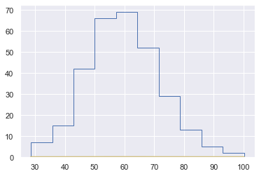

```python
# Visualising a normal distribution with mean 60 and sigma 12
mu, sigma = 60, 12
s = np.random.normal(mu, sigma, 300)

# Create the bins and histogram
count, bins, ignored = plt.hist(s, 10, histtype='step')

# Plot the distribution curve
plt.plot(bins, 1/(sigma * np.sqrt(2 * np.pi)) *
    np.exp( - (bins - mu)**2 / (2 * sigma**2) ), linewidth=3, color='y')
plt.show()
```

```python
# Identifying the values
s
```

[output not shown]

[output cut: 20 more lines]

[output not shown]

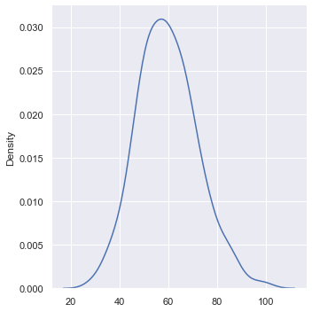

```python
# Looking at the kde plot
sns.displot(s, kind='kde')
```

```python
# Randomising the process of creating a normal distribution of this example a thousand times
mu, sigma = 60, 12
# Storing the sum of all the percentage values for marks greater than 80
err = 0

for n in range(1000):
    s = np.random.normal(mu, sigma, 300)
    err = err + (len(s[s>80])/300)

# Finding the mean over 1000 repetitions
err/1000
```

```
0.048316666666666806
```

```python
# Randomising the process of creating a normal distribution of this example a thousand times
mu, sigma = 60, 12
# Storing the sum of all the percentage values for marks less than 50
err = 0

for n in range(1000):
    s = np.random.normal(mu, sigma, 300)
    err = err + (len(s[s<50])/300)

# Finding the mean over 1000 repetitions
err/1000
```

```
0.20247666666666708
```

```python
# 90 percentile position
percentile_loc = int(0.9*300)

# Randomising the process of creating a normal distribution of this example a thousand times
mu, sigma = 60, 12
# Storing the sum of all the cutoff marks for top 10 percentile
err = 0

for n in range(1000):
    s = np.random.normal(mu, sigma, 300)
    s.sort()
    err = err + (s[percentile_loc])

# Finding the mean over 1000 repetitions
err/1000
```

```
75.43553024852324
```

#### A. What is the percentage of students who score more than 80.

```python
# Creating the mean, standard deviation and answer variables
mean = 60
sd = 12
ans = 1 - stats.norm.cdf(80, loc=mean, scale=sd)

# Printing the answer
print("The percentage of students who score more than 80 is %2.4f%%" %(ans*100))
```

```
The percentage of students who score more than 80 is 4.7790%
```

#### B. What is the percentage of students who score less than 50.

```python
# Creating the answer variable
ans = stats.norm.cdf(50, loc=mean, scale=sd)

# Printing the answer
print("The percentage of students who score less than 50 is %2.4f%%" %(ans*100))
```

```
The percentage of students who score less than 50 is 20.2328%
```

#### C. What should be the distinction mark if the highest 10% of students are to be awarded distinction?

```python
# Creating the answer variable
ans = stats.norm.ppf(0.9, loc=60, scale=12)

# Printing the answer
print("The distinction mark if the highest 10%% of students are to be awarded distinction is %2.0f%%" %(ans))
```

```
The distinction mark if the highest 10% of students are to be awarded distinction is 75%
```

```python
# Removing Variables
del mu, sigma, n, count, bins, ignored, s, err, percentile_loc, mean, sd, ans
```

#### 6. Question: Explain 1 real life industry scenario [other than the ones mentioned above] where you can use the concepts learnt in this module of Applied statistics to get a data driven business solution.

###### I helped in building an activity (Intervention) which would be used to complete a learning process. One way to check the effectiveness of this activity would be to test the participants on specific questions, before and after the Intervention and check if their is a significant increase in their understanding. We can check for significance using a paired sample t test. Of course this type of pre and post testing is used quite commonly in research and education industries.

# PART TWO

# PROJECT BASED

# TOTAL SCORE - 15

## In this analysis we will first clean the data, then we will find out the best performing team (through univariate and bivariate analysis), then we will create more features and finally compare the highest performing teams and try to predict more younger teams with similar stats to the established, best performing teams.

### Our Analysis will focus on Best qualities and not the Worst qualities as our suggestion will orient around good qualities and normal behaviour only.

#### 1. Read the data set, clean the data and prepare a final dataset to be used for analysis.

```python
# Loading the dataset in df_bb with '-' as Null values
df_bb = pd.read_csv("DS - Part2 - Basketball.csv", na_values='-')

# Converting TeamLaunch into more meaningful format. Wherever TeamLaunch is more than 1 year we keep the last date as the year.
# Initialising a list to collect all the new values
TeamLaunch_list = []

# Looping through TeamLaunch and extracting the meaningful format
for val in df_bb["TeamLaunch"]:
    TeamLaunch_list.append(val[:2]+val[-2:])

# Assigning the new list to the column TeamLaunch
df_bb["TeamLaunch"] = TeamLaunch_list

# Converting the column TeamLaunch to year
df_bb["TeamLaunch"] = pd.to_datetime(df_bb["TeamLaunch"]).dt.year

# Converting Null Float to 0
df_bb.iloc[:, 2:11] = df_bb.iloc[:, 2:11].fillna(0)

# Converting float columns to integer datatype
df_bb = df_bb.astype({"Score": 'int', "PlayedGames":'int', "WonGames":'int', "DrawnGames":'int', "LostGames":'int',
                      "BasketScored":'int', "BasketGiven":'int', "TournamentChampion":'int', "Runner-up":'int'})

# Visualising the Clean DataFrame information
df_bb.info()
```

```
<class 'pandas.core.frame.DataFrame'>
RangeIndex: 61 entries, 0 to 60
Data columns (total 13 columns):
 #   Column               Non-Null Count  Dtype
---  ------               --------------  -----
 0   Team                 61 non-null     object
 1   Tournament           61 non-null     int64
 2   Score                61 non-null     int32
 3   PlayedGames          61 non-null     int32
 4   WonGames             61 non-null     int32
 5   DrawnGames           61 non-null     int32
 6   LostGames            61 non-null     int32
 7   BasketScored         61 non-null     int32
 8   BasketGiven          61 non-null     int32
 9   TournamentChampion   61 non-null     int32
 10  Runner-up            61 non-null     int32
 11  TeamLaunch           61 non-null     int64
 12  HighestPositionHeld  61 non-null     int64
dtypes: int32(9), int64(3), object(1)
memory usage: 4.2+ KB
```

##### This dataframe (df_bb) will be used for further analysis

#### 2. Perform detailed statistical analysis and EDA using univariate, bi-variate and multivariate EDA techniques to get a data driven insights on recommending which teams they can approach which will be a deal win for them.. Also as a data and statistics expert you have to develop a detailed performance report using this data.

```python
# Visualising general statistics of each column
df_bb.describe()
```

|  | Tournament | Score | PlayedGames | WonGames | DrawnGames | LostGames | BasketScored | BasketGiven | TournamentChampion | Runner-up | TeamLaunch | HighestPositionHeld |
| --- | --- | --- | --- | --- | --- | --- | --- | --- | --- | --- | --- | --- |
| count | 61.000000 | 61.000000 | 61.000000 | 61.000000 | 61.000000 | 61.000000 | 61.000000 | 61.000000 | 61.000000 | 61.000000 | 61.000000 | 61.000000 |
| mean | 24.000000 | 901.426230 | 796.819672 | 303.967213 | 188.934426 | 303.754098 | 1140.344262 | 1140.229508 | 1.426230 | 1.409836 | 1958.114754 | 7.081967 |
| std | 26.827225 | 1134.899121 | 876.282765 | 406.991030 | 201.799477 | 294.708594 | 1506.740211 | 1163.710766 | 5.472535 | 4.540107 | 28.200531 | 5.276663 |
| min | 1.000000 | 0.000000 | 0.000000 | 0.000000 | 0.000000 | 0.000000 | 0.000000 | 0.000000 | 0.000000 | 0.000000 | 1900.000000 | 1.000000 |
| 25% | 4.000000 | 96.000000 | 114.000000 | 34.000000 | 24.000000 | 62.000000 | 153.000000 | 221.000000 | 0.000000 | 0.000000 | 1935.000000 | 3.000000 |
| 50% | 12.000000 | 375.000000 | 423.000000 | 123.000000 | 95.000000 | 197.000000 | 430.000000 | 632.000000 | 0.000000 | 0.000000 | 1951.000000 | 6.000000 |
| 75% | 38.000000 | 1351.000000 | 1318.000000 | 426.000000 | 330.000000 | 563.000000 | 1642.000000 | 1951.000000 | 0.000000 | 0.000000 | 1978.000000 | 10.000000 |
| max | 86.000000 | 4385.000000 | 2762.000000 | 1647.000000 | 633.000000 | 1070.000000 | 5947.000000 | 3889.000000 | 33.000000 | 25.000000 | 2018.000000 | 20.000000 |

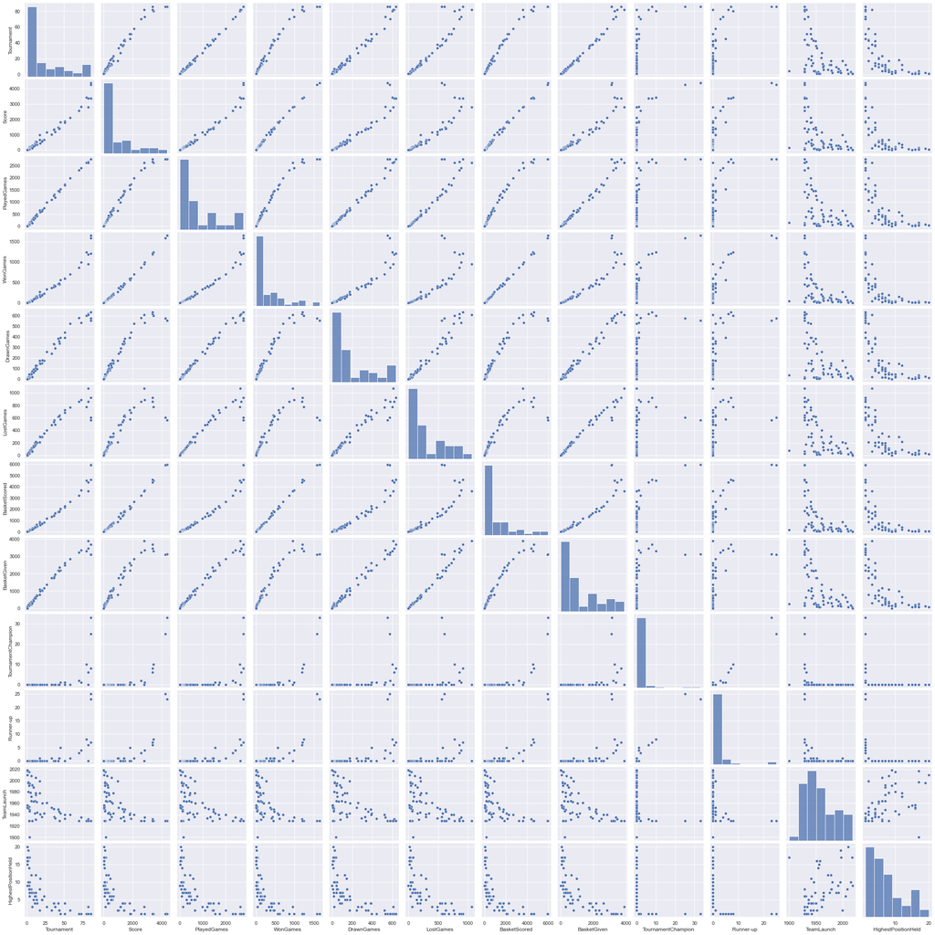

```python
# Let us do a multivariate analysis (which includes univariate and bivariate) to see the realtionship between different columns
sns.pairplot(df_bb)
```

##### Inference 1: Tournament and Games played (Information wise these are similar features except that GamesPlayed is a multiple of Tournament) have a very healthy linear relationship with Score, WonGames and BasketScored. In fact BasketGiven and LostGames which are negative features seem to show a dip between Teams who have played a higher number of Tournaments. Which would suggest that below a threshold number of tournaments teams have a linear Relationship between Tournament and Games played vs positive (Score, WonGames and BasketScored) and negative qualities (BasketGiven and LostGames) as mentioned before.

##### Inference 2: Interestingly a lot of bivariate graphs above we can find a cluster of two dots which are seperated from the crowd. In Univariate analysis of TournamentChampion and Runner-up also we notice a similiar cluster at the higher end (Although here it does not suggest the cluster is of only 2). This is definitely the kind of teams we should target and analyse further.

##### From Inference 2 we will dive deeper to find the teams

##### Performing more high precision bivariate analysis

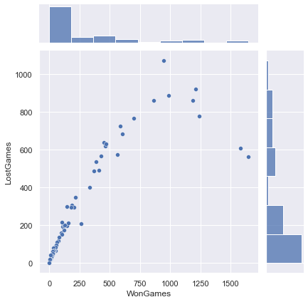

```python
# Analysing WonGames vs LostGames
sns.jointplot(x=df_bb["WonGames"], y=df_bb["LostGames"])
```

##### Inference 3: Two teams exist which have improved on the art of winning since they won a lot of games and lost few as well.

##### From Inference 3 we will search for these two teams

##### It is evident from the previous graph that these teams have also won the most number of games

```python
# Printing the top two WonGames Team names
print("Two Highest performance teams are : %s & %s" %(df_bb.nlargest(2, ["WonGames"])["Team"][0],
                                                      df_bb.nlargest(2, ["WonGames"])["Team"][1]))
```

```
Two Highest performance teams are : Team 1 & Team 2
```

#### Now let us create some new features for analysis

##### The limitation of the previous features are apparent. Which is that most teams cannot be compared with each other with the available information. So we will create new stats and features to achieve the same. We will apply these stats to a copy so as to not affect the original.

```python
# Creating a copy
df_bb_stats = df_bb.copy()
```

```python
# New stat Win Ratio which is wins per game
df_bb_stats["Win_Ratio"] = df_bb_stats["WonGames"]/df_bb_stats["PlayedGames"]

# New stat Loss Ratio which is loss per game
df_bb_stats["Loss_Ratio"] = df_bb_stats["LostGames"]/df_bb_stats["PlayedGames"]

# New stat Draw Ratio which is draws per game
df_bb_stats["Draw_Ratio"] = df_bb_stats["DrawnGames"]/df_bb_stats["PlayedGames"]

# New stat Basket Given Ratio which is Basket Given per game
df_bb_stats["BasketGiven_Ratio"] = df_bb_stats["BasketGiven"]/df_bb_stats["PlayedGames"]

# New stat Basket Scored Ratio which is Basket Scored per game
df_bb_stats["BasketScored_Ratio"] = df_bb_stats["BasketScored"]/df_bb_stats["PlayedGames"]

# New stat Score to Basket which is average points recieved per basket (This is useful as basket points range from 1 to 4)
df_bb_stats["Score2Basket"] = df_bb_stats["Score"]/df_bb_stats["BasketScored"]

# New stat Games to Tournament which is games played per tournament (This is useful since more a team plays er tournament more exposure they get)
df_bb_stats["Games2Tournament"] = df_bb_stats["PlayedGames"]/df_bb_stats["Tournament"]

# New stat Tournament years, this is the number years from inception to current year and hence the number of available years to play in the tournament
df_bb_stats["Tournyears"] = 2018 - df_bb_stats["TeamLaunch"]
```

#### Reducing the number of columns

##### Ratios will replace the original columns so as to look at more useful data

##### Removing Games Played since it is a commonly part of Ratio and Tournament gives similar information

```python
# Dropping columns
df_bb_stats.drop(["PlayedGames", "Score", "WonGames", "LostGames", "DrawnGames", "BasketGiven", "BasketScored"], axis=1, inplace=True)
```

```python
# Visualising Dataframe information
df_bb_stats.info()
```

```
<class 'pandas.core.frame.DataFrame'>
RangeIndex: 61 entries, 0 to 60
Data columns (total 14 columns):
 #   Column               Non-Null Count  Dtype
---  ------               --------------  -----
 0   Team                 61 non-null     object
 1   Tournament           61 non-null     int64
 2   TournamentChampion   61 non-null     int32
 3   Runner-up            61 non-null     int32
 4   TeamLaunch           61 non-null     int64
 5   HighestPositionHeld  61 non-null     int64
 6   Win_Ratio            60 non-null     float64
 7   Loss_Ratio           60 non-null     float64
 8   Draw_Ratio           60 non-null     float64
 9   BasketGiven_Ratio    60 non-null     float64
 10  BasketScored_Ratio   60 non-null     float64
 11  Score2Basket         60 non-null     float64
 12  Games2Tournament     61 non-null     float64
 13  Tournyears           61 non-null     int64
dtypes: float64(7), int32(2), int64(4), object(1)
memory usage: 6.3+ KB
```

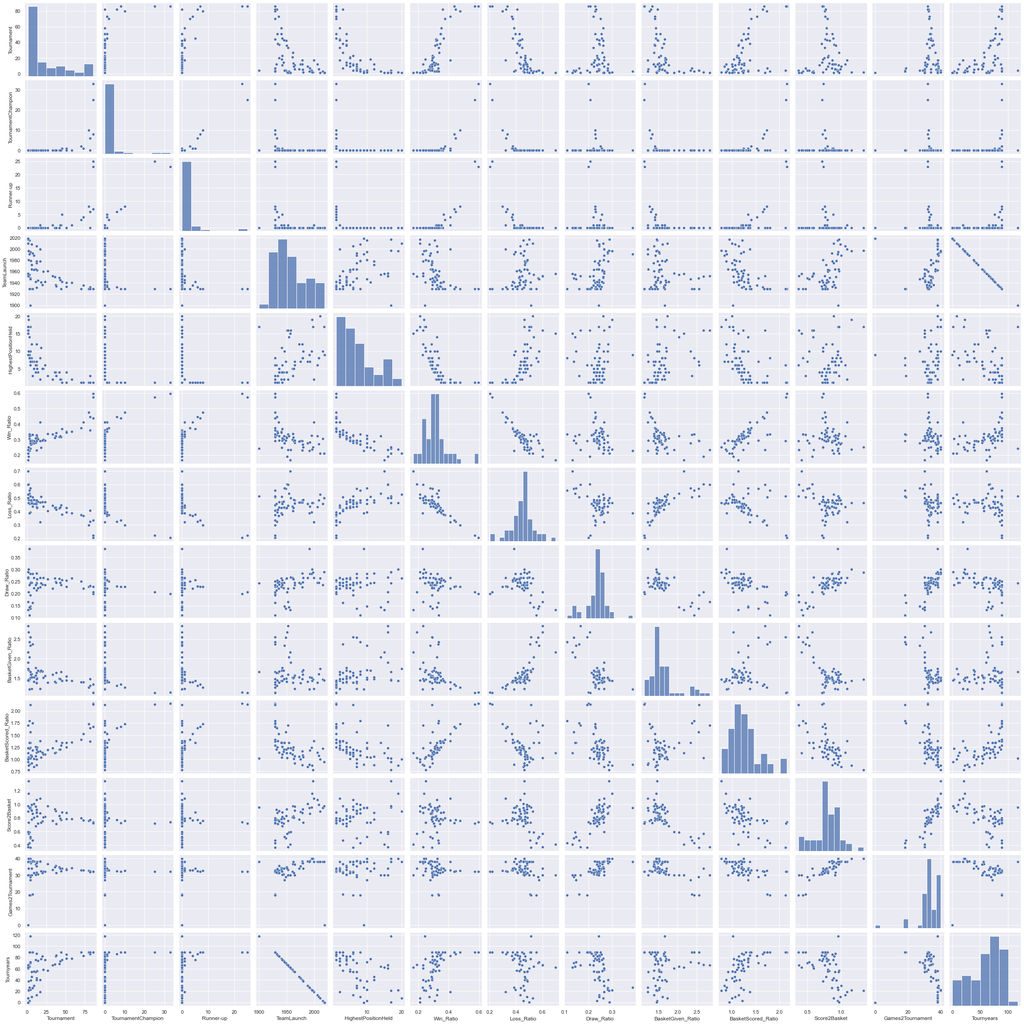

```python
# Performing Multivariate Analysis (which includes univariate and bivariate)
sns.pairplot(df_bb_stats)
```

#### From here we try to group the teams based on stats

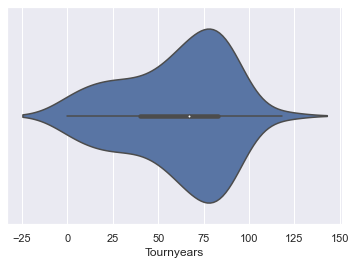

```python
# Visualising a violinplot of TournYears
sns.violinplot(x=df_bb_stats["Tournyears"])
```

##### Inference 5 there are more older teams than younger ones

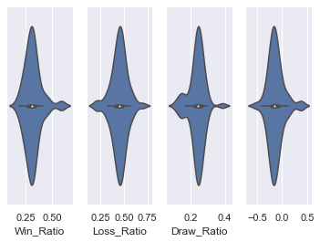

```python
# Visualising violinplots of Win, Loss and Draw Ratio

#plot 1:

plt.subplot(1, 4, 1)
sns.violinplot(x=df_bb_stats["Win_Ratio"])

#plot 2:

plt.subplot(1, 4, 2)
sns.violinplot(x=df_bb_stats["Loss_Ratio"])

#plot 3:

plt.subplot(1, 4, 3)
sns.violinplot(x=df_bb_stats["Draw_Ratio"])

#plot 4:

plt.subplot(1, 4, 4)
sns.violinplot(x=df_bb_stats["Win_Ratio"] - df_bb_stats["Loss_Ratio"])

plt.show()
```

##### Inference 6 Win Ratio Distribution is pretty normally distributed with a slight Right Skew While Draw Ratio is pretty normal with two minor peaks on each side and Loss Ratio is normally distributed. However most importantly we see that Win_Ratio-LossRatio peaks are below the 0 mark which mean that majority of teams have a higher Loss Ratio than Win Ratio.

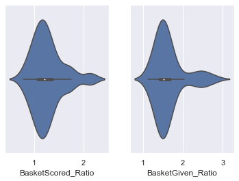

```python
# Visualising violinplots of Basket Scored and Given

#plot 1:

plt.subplot(1, 2, 1)
sns.violinplot(x=df_bb_stats["BasketScored_Ratio"])

#plot 2:

plt.subplot(1, 2, 2)
sns.violinplot(x=df_bb_stats["BasketGiven_Ratio"])

plt.show()
```

##### This gives us the team's relative scoring style based on their peers

```python
# Creating the required bins
bins= [0.0,0.4,0.6,0.9,1.01]

# Creating the label based on bins
labels = ['Not_Aggressive','Moderate','Aggressive','Very_Aggressive']

# Creating a new column Offence_Style with classes 'Not_Aggressive', 'Moderate', 'Aggressive', 'Very_Aggressive'
df_bb_stats["Offence_Style"] = pd.cut(df_bb_stats["BasketGiven_Ratio"].rank(pct=True, na_option="top"), bins=bins, labels=labels, right=False)
```

##### This gives us the team's relative defense style based on their peers

```python
# Creating the required bins
bins= [0.0,0.4,0.6,0.9,1.01]

# Creating the label based on bins
labels = ['Not_Defensive','Moderate','Defensive','Very_Defensive']

# Creating a new column Offence_Style with classes 'Not_Aggressive', 'Moderate', 'Aggressive', 'Very_Aggressive'
df_bb_stats["Defence_Style"] = pd.cut(df_bb_stats["BasketGiven_Ratio"].rank(pct=True, na_option="top", ascending=False), bins=bins, labels=labels, right=False)
```

#### From Inference 6 we will not classify Win and Loss Ratio but instead mark only the teams with a positive Win to Loss Ratio as Good. No further classification of good will be done is good itself is only 13% of the data.

##### This gives us the relative performance of a team amongst its peers

```python
# Initialising a new column Performance with all values set to Bad
df_bb_stats["Performance"] = ["Bad"]*len(df_bb_stats)

# Marking all positive Win to Loss Ratio as Good
df_bb_stats["Performance"][(df_bb_stats["Win_Ratio"] - df_bb_stats["Loss_Ratio"]) >= 0] = "Good"
```

#### From Inference 6 we will classify teams with a lot of draws as Boring teams and others Not Boring. This classification we will do down the middle and hence according of Median

##### This gives us the relative result oriented performance of a team amongst its peers

```python
# Calculating the Median value to be compared against
median = df_bb_stats["Draw_Ratio"].median()

# Create a new Column Engagement which will be classified as Boring or Not Boring
df_bb_stats["Engagement"] = df_bb_stats["Draw_Ratio"].apply(lambda x: "Boring" if x >= median else "Not_Boring")
```

### Let us do some quick visualisation with out new attributes and classes before we start our recommendation

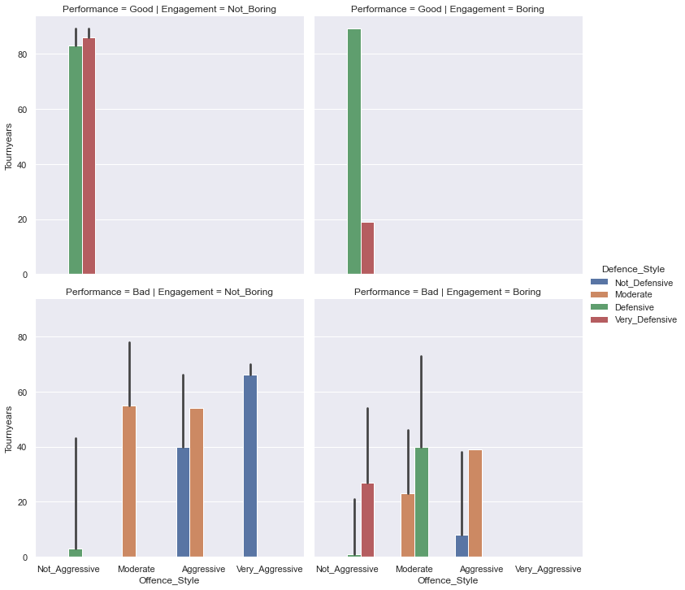

```python
# Creating a multivariate Categorical Plot
sns.catplot(x="Offence_Style",
               y = "Tournyears",
               hue="Defence_Style",
               row="Performance",
               col="Engagement",
               data=df_bb_stats,
               kind="bar", estimator=np.min);
```

##### Inference 8: Generally Teams with with a Defensive focus tend to do have a better Win Ratio against Loss Ratio. This also evident from the fact that our two top performers from Inference 3 were also extremely Defensive type

```python
# Looking at pivot table to see Playing Style count distribution
pd.pivot_table(df_bb_stats[df_bb_stats["Engagement"] == "Not_Boring"], values='Tournyears', index=["Offence_Style"], columns=["Defence_Style"], aggfunc=len)
```

| Defence_Style Offence_Style | Not_Defensive | Moderate | Defensive | Very_Defensive |
| --- | --- | --- | --- | --- |
| Not_Aggressive | 1.0 | NaN | 4.0 | 4.0 |
| Moderate | NaN | 4.0 | NaN | NaN |
| Aggressive | 10.0 | 1.0 | NaN | NaN |
| Very_Aggressive | 7.0 | NaN | NaN | NaN |

##### Inference 9: Very Aggressive playing style generally means that they give away a lot of Baskets as well. As a matter of fact Very_Aggressive playing style means that they are not Defensive minded at all.

#### So now let us get down to some suggestions. Based on the Vision and Mission of Company_X, we know Company_X is an aggressive player in the Market, however we want to recommend a healthy mixture of suggestions.

#### We will first recommend some Good Performers. In this area from Inference 3 the Best Win against Loss are Team 1 & Team 2

```python
# Printing the top two WonGames Team names
print("Two Highest performance teams are : %s & %s" %(df_bb.nlargest(2, ["WonGames"])["Team"][0],
                                                      df_bb.nlargest(2, ["WonGames"])["Team"][1]))
```

```
Two Highest performance teams are : Team 1 & Team 2
```

#### Team 1 & Team 2 are also old teams so they may have existing contracts. So let us now focus on the rising talents. For this we will look at teams which are less than 20 years old but with a good performance

```python
# Slice dataset to the required selection
selection = df_bb_stats[(df_bb_stats["Tournyears"] <= 20) & (df_bb_stats["Performance"] == "Good")]

# Printing result
print("This is a rising star, hence it is also a riskier bet, but%s has already been a Runner-up %d times" %(selection["Team"].to_string(index=False), selection["Runner-up"]))
print("%s plays about %2.2f games per tournament which means they will be a regular fixture" %(selection["Team"].to_string(index=False), selection["Games2Tournament"]))
```

```
This is a rising star, hence it is also a riskier bet, but Team 21 has already been a Runner-up 1 times
 Team 21 plays about 38.00 games per tournament which means they will be a regular fixture
```

#### Now that we have two experienced teams and a rising star. Let us look at style of Play.

#### We will now choose 2 Very_Aggressive Playing style teams with the highest Score recorded till date. Very_Aggressive style will be a good culture fit with Company X

```python
# Slice dataset to the required selection (Using our knowledge that df_bb and df_bb_stats are copies we slice confidently)
selection = df_bb[df_bb_stats["Offence_Style"].isin(["Very_Aggressive"])].nlargest(2, "Score")

# Printing result
print("This is a team which plays aggressively and hence playing style is more exciting just like Company X")
print("%s & %s plays very agressively on the field and generally Score a lot of Baskets" %(selection.loc[selection.index[0], "Team"], selection.loc[selection.index[1], "Team"]))
```

```
This is a team which plays aggressively and hence playing style is more exciting just like Company X
Team 45 & Team 47 plays very agressively on the field and generally Score a lot of Baskets
```

#### 3. Please include any improvements or suggestions to the association management on quality, quantity, variety, velocity, veracity etc. on the data points collected by the association to perform a better data analysis in future

###### The data could be masked data and not the entire data. This seems to be true since in many cases the Total Score is less than the number of baskets scored, and Games Played compared to Score, Basket Scored, Basket Given etc seems to be quite low as well.

###### Traditionally a Basketball game could have 1, 2, 3 or even 4 (rarely) points per basket. An analysis where we could determine how a team scores its points (How many 3 pointers) would give a wealth of knowledge on the team itself. This was not possible in this dataset and elements which would help us analyse the team playing style more would be very helpful.

###### To sum up more data and more complete data would have greatly improved this dataset. Also more information on clients motivations to sponsor teams which play in a tournament organised by the client itself (despite the conflict of interest) would help us understand what to recommend.

```python
# Removing Variables
del TeamLaunch_list, df_bb, df_bb_stats, selection, bins, median, labels
```

# PART THREE

# PROJECT BASED

# TOTAL SCORE - 30

#### 1. Data warehouse:

##### • Read the CSV file.

```python
# Reading the csv file into dataframe

# Error handling for missing csv
try:
    df_stup = pd.read_csv("DS - Part3 - CompanyX_EU.csv")
except OSError as e:

    # Provide instructions if file not found
    file_path = os.path.join(os.path.abspath(''))
    print("Please place the file named <DS - Part3 - CompanyX_EU.csv> at the path", file_path)
```

#### 2. Data exploration:

##### • Check the datatypes of each attribute.

```python
# Checking the datatypes of each attribute through information
df_stup.info()
```

```
<class 'pandas.core.frame.DataFrame'>
RangeIndex: 662 entries, 0 to 661
Data columns (total 6 columns):
 #   Column          Non-Null Count  Dtype
---  ------          --------------  -----
 0   Startup         662 non-null    object
 1   Product         656 non-null    object
 2   Funding         448 non-null    object
 3   Event           662 non-null    object
 4   Result          662 non-null    object
 5   OperatingState  662 non-null    object
dtypes: object(6)
memory usage: 31.2+ KB
```

##### • Check for null values in the attributes.

Please note that the automated version of looking for null values was created only after a thorough offline manual check

```python
# Checking for null values in attributes

# Nan has already been handled through pd.read_csv(), currently looking for other common signals of a nan value

# Creating a list of common signals of Null
null_list = ["-", " ", "  "]

# Looping through all columns available
for idx in range(len(df_stup.columns)):
    # Printing useful information
    print("Column Name : ", df_stup.columns[idx])
    print("Verdict")
    flag = 0

    # Looping through all values in null_list
    for elem in null_list:
        # Comparing each value of null_list all unique values of a column
        if elem in df_stup[df_stup.columns[idx]].unique():

            # Printing the the null value signal found and encouraging manual detection
            print("Null Found:", elem, " Manually check Values")
            print(df_stup[df_stup.columns[idx]].unique())
            flag = 1
            break

    # Printing helpful information when null values are not found
    if flag == 0:
        print("No null values")

    # For cosmetic purposes inserting blank line
    print("\n")
```

```
Column Name :  Startup
Verdict
No null values


Column Name :  Product
Verdict
No null values


Column Name :  Funding
Verdict
No null values


Column Name :  Event
Verdict
Null Found: -  Manually check Values
['Disrupt SF 2013' 'Disrupt NYC 2013' 'Disrupt SF 2016' 'Disrupt NY 2016'
 'TC50 2009' 'Disrupt Beijing 2011' 'TC40 2007' 'Disrupt NYC 2012'
 'TC50 2008' 'Hardware Battlefield 2014' 'Disrupt SF 2015'
 'Disrupt London 2016' 'Disrupt NYC 2014' 'Disrupt SF 2012'
 'Disrupt SF 2014' 'Disrupt SF 2011' 'Disrupt NYC 2010' 'Disrupt NY 2015'
 'Disrupt NYC 2011' 'Disrupt EU 2013' 'Disrupt SF 2010' '-'
 'Hardware Battlefield 2015' 'Hardware Battlefield 2016' 'Disrupt EU 2014'
 'Disrupt London 2015']


Column Name :  Result
Verdict
No null values


Column Name :  OperatingState
Verdict
No null values
```

#### 3. Data preprocessing & visualisation:

##### • Drop the null values.

```python
# Dropping Null values and rows with value "-" in Event
df_stup = df_stup[df_stup["Event"] != "-"].dropna()

# Checking new attribute information
df_stup.info()
```

```
<class 'pandas.core.frame.DataFrame'>
Int64Index: 440 entries, 1 to 661
Data columns (total 6 columns):
 #   Column          Non-Null Count  Dtype
---  ------          --------------  -----
 0   Startup         440 non-null    object
 1   Product         440 non-null    object
 2   Funding         440 non-null    object
 3   Event           440 non-null    object
 4   Result          440 non-null    object
 5   OperatingState  440 non-null    object
dtypes: object(6)
memory usage: 24.1+ KB
```

##### • Convert the ‘Funding’ features to a numerical value.

Please note that offline verification of the pattern has been carried out before accepting the following pieces of code

```python
# Initialising a list which will be used to make necessary calculation for the new 'Funding' feature
Funding_list = []

# Looping through each value of Funding column to extract necessary information
for val in df_stup["Funding"]:

    # Checking if last string is K(thousand), M(million) & B(billion)
    if val[-1] == 'K':
        # Trimming each value of this condition to get float value and then multiplying by 1000(K) to get the required integer
        Funding_list.append(int(float(val[1:-1])*1000))
    elif val[-1] == 'M':
        # Trimming each value of this condition to get float value and then multiplying by 100K(M) to get the required integer
        Funding_list.append(int(float(val[1:-1])*1000000))
    elif val[-1] == 'B':
        # Trimming each value of this condition to get float value and then multiplying by 100M(B) to get the required integer
        Funding_list.append(int(float(val[1:-1])*1000000000))
```

```python
# Replacing the old 'Funding' attribute values with new values of Funding_list
df_stup["Funding"] = Funding_list

# Checking new attribute information
df_stup.info()
```

```
<class 'pandas.core.frame.DataFrame'>
Int64Index: 440 entries, 1 to 661
Data columns (total 6 columns):
 #   Column          Non-Null Count  Dtype
---  ------          --------------  -----
 0   Startup         440 non-null    object
 1   Product         440 non-null    object
 2   Funding         440 non-null    int64
 3   Event           440 non-null    object
 4   Result          440 non-null    object
 5   OperatingState  440 non-null    object
dtypes: int64(1), object(5)
memory usage: 24.1+ KB
```

##### • Plot box plot for funds in million.

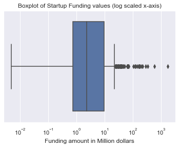

```python
# Displaying the box plot for funds in million
sns.boxplot(x=df_stup["Funding"]/1000000)
plt.xscale("log")
plt.title("Boxplot of Startup Funding values (log scaled x-axis)")
plt.xlabel("Funding amount in Million dollars")
plt.show()
```

##### • Get the lower fence from the box plot.

```python
# Get quartile 3 and quartile 1
q3, q1 = np.percentile(df_stup["Funding"], [75 ,25])

# calculate interquartile range
iqr = q3 - q1

# Display lower fence from the boxplot
print("Lower Fence is 0") if (q1 - 1.5*iqr) < 0 else print("Lower Fence is ", (q1 - 1.5*iqr))
```

```
Lower Fence is 0
```

##### • Check number of outliers greater than upper fence.

```python
# Calculate upper fence from iqr and displaying the number of values greater than upper fence
print("Number of outliers greater than upper fence is ", sum(df_stup["Funding"] > q3 + 1.5*iqr))
```

```
Number of outliers greater than upper fence is  60
```

##### • Drop the values that are greater than upper fence.

```python
# Values greater than upper fence are the same values which are not below or equal to the upper fence
# Hence keeping values which are below or equal to the upper fence
df_stup[df_stup["Funding"] <= q3 + 1.5*iqr]
```

|  | Startup | Product | Funding | Event | Result | OperatingState |
| --- | --- | --- | --- | --- | --- | --- |
| 1 | 3DLT | 3dlt.com | 630000 | Disrupt NYC 2013 | Contestant | Closed |
| 3 | 3Dprintler | 3dprintler.com | 1000000 | Disrupt NY 2016 | Audience choice | Operating |
| 5 | 5to1 | 5to1.com | 19300000 | TC50 2009 | Contestant | Acquired |
| 10 | AdhereTech | adheretech.com | 1800000 | Hardware Battlefield 2014 | Contestant | Operating |
| 11 | AdRocket | adrocket.com | 1000000 | TC50 2008 | Contestant | Closed |
| ... | ... | ... | ... | ... | ... | ... |
| 642 | Xendo | xendo.com | 28000 | Disrupt SF 2014 | Contestant | Acquired |
| 645 | Yap | yapme.com | 10000000 | TC40 2007 | Contestant | Closed |
| 646 | YayPay Inc | yaypay.com | 900000 | Disrupt London 2015 | Contestant | Operating |
| 657 | Zivity | zivity.com | 8000000 | TC40 2007 | Contestant | Operating |
| 660 | Zula | zulaapp.com | 3400000 | Disrupt SF 2013 | Audience choice | Operating |

380 rows × 6 columns

##### • Plot the box plot after dropping the values.

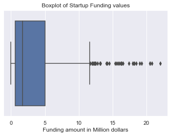

```python
# Displaying the box plot after dropping the values.
sns.boxplot(x=df_stup[df_stup["Funding"] <= q3 + 1.5*iqr]["Funding"]/1000000)
plt.title("Boxplot of Startup Funding values")
plt.xlabel("Funding amount in Million dollars")
plt.show()
```

##### • Check frequency of the OperatingState features classes.

```python
# Calculate the state and frequency from OperatingState
state, freq = np.unique(df_stup["OperatingState"], return_counts=True)

# Initialising a dictionary for better visualisation of the States and frequency
OperatingState_dict = {}

# Create the dictionary with state and freq values
for key, value in zip(state, freq):
    OperatingState_dict[key] = value

# Display the frequency of the OperatingState features classes
print(OperatingState_dict)
```

```
{'Acquired': 66, 'Closed': 57, 'Ipo': 4, 'Operating': 313}
```

##### • Plot a distribution plot for Funds in million.

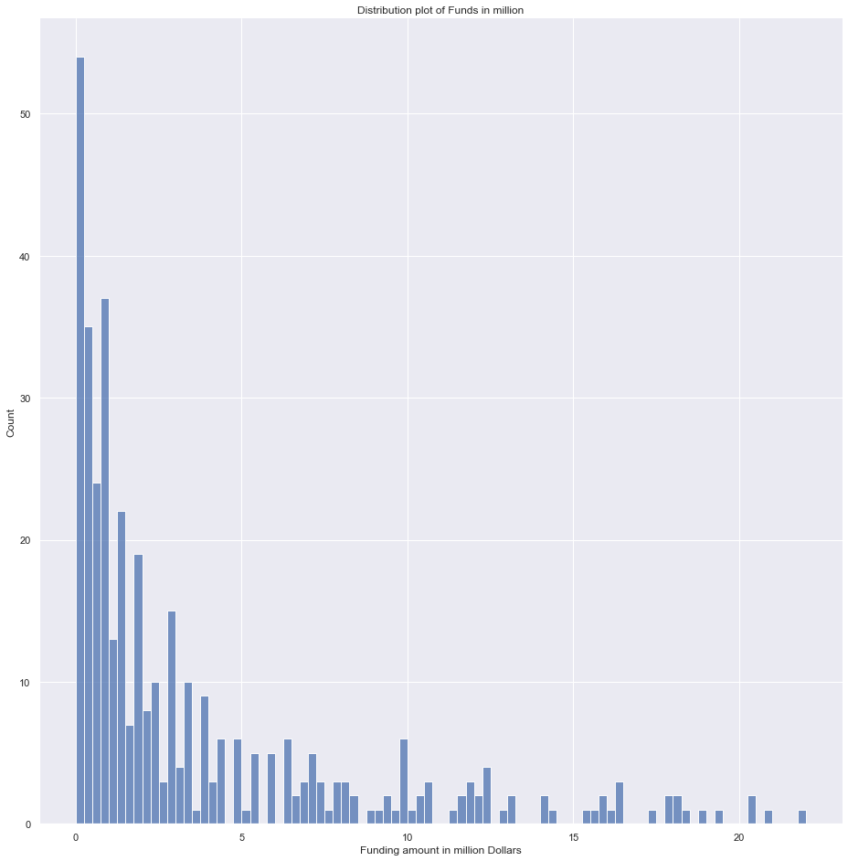

```python
# Plotting the distribution plot for Funds in million
sns.displot(df_stup[df_stup["Funding"] <= q3 + 1.5*iqr]["Funding"]/1000000,
            bins=88,
            height=13)

# Setting the cosmetics around the plot
plt.title("Distribution plot of Funds in million")
plt.xlabel("Funding amount in million Dollars")
plt.show()
```

##### • Plot distribution plots for companies still operating and companies that closed.

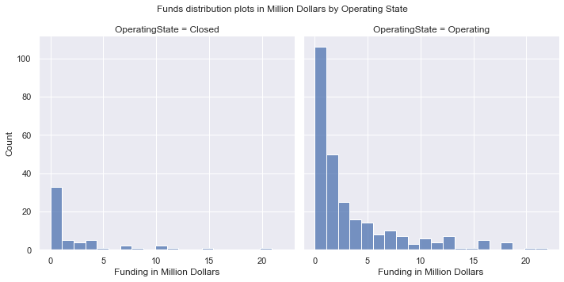

```python
# Create a new dataset with the required slicing and changes for graph
data = df_stup[(df_stup["Funding"] <= q3 + 1.5*iqr) & (df_stup["OperatingState"].isin(["Operating", "Closed"]))].copy()
data["Funding in Million Dollars"] = data["Funding"]/1000000

# Plot distribution plots for companies still operating and companies that closed.
sns.displot(x="Funding in Million Dollars", col="OperatingState", data=data)

# Add graph design for better readability
plt.subplots_adjust(top=0.87)
plt.suptitle('Funds distribution plots in Million Dollars by Operating State')
plt.show()
```

#### 4. Statistical analysis:

##### • Is there any significant difference between Funds raised by companies that are still operating vs companies that closed down?

```
Write the null hypothesis and alternative hypothesis.
Test for significance and conclusion
```

###### Ho is μ(operating) = μ(closed)

###### Ha is μ(operating) ≠ μ(closed)

###### Testing our Null Hypothesis against a 90% significance

```python
# Printing pairwise_tukeyhsd output of the groups with alpha 0.1
print(pairwise_tukeyhsd(df_stup["Funding"], df_stup["OperatingState"], alpha=0.1))
```

```
              Multiple Comparison of Means - Tukey HSD, FWER=0.10
===============================================================================
 group1    group2      meandiff    p-adj       lower          upper      reject
-------------------------------------------------------------------------------
Acquired    Closed   -9954723.7815    0.9  -47556592.8574  27647145.2944  False
Acquired       Ipo  124562106.0606 0.0389    17480881.415 231643330.7063   True
Acquired Operating     6187049.821    0.9  -21980024.6015  34354124.2435  False
  Closed       Ipo  134516829.8421  0.022   26953616.7532  242080042.931   True
  Closed Operating   16141773.6025 0.5903  -13805517.0915  46089064.2965  False
     Ipo Operating -118375056.2396 0.0473 -223014094.5261 -13736017.9531   True
-------------------------------------------------------------------------------
```

###### Based on the Advice from Tukey HSD test, in Closed to Operating row, we should not reject the Null Hypothesis μ(operating) = μ(closed)

###### Thus our conclusion is that the difference of mean in Funding between Operating and Closed Companies is not Significant. Which might suggest that the investors capacity and excitement to fund is not affected by example of Closed Companies.

##### • Make a copy of the original data frame.

```python
# Making a copy
df_stup_cpy = df_stup.copy()
```

##### • Check frequency distribution of Result variable.

```python
# Calculate the state and frequency from Result variable
res, freq = np.unique(df_stup["Result"], return_counts=True)

# Initialising a dictionary for better visualisation of the results and frequency
Result_dict = {}

# Create the dictionary with result and freq values
for key, value in zip(res, freq):
    Result_dict[key] = value

# Display the frequency of the Result variable
print(Result_dict)
```

```
{'Audience choice': 23, 'Contestant': 311, 'Finalist': 64, 'Runner up': 18, 'Winner': 24}
```

##### • Calculate percentage of winners that are still operating and percentage of contestants that are still operating

```python
# Calculating the proportion size based on winner and contestant (Denominator)
winner_size = len(df_stup[df_stup["Result"] == "Winner"])
contestant_size = len(df_stup[df_stup["Result"] == "Contestant"])

# Calculating the size of the required event of Operating while winner or contestant (Numerator)
winner2operating_size = len(df_stup[(df_stup["Result"] == "Winner") & (df_stup["OperatingState"] == "Operating")])
contestant2operating_size = len(df_stup[(df_stup["Result"] == "Contestant") & (df_stup["OperatingState"] == "Operating")])

# Calculating the proportion of Operating winner and Operating contestant (Numerator)
pct_win2oprt = (winner2operating_size/winner_size)
pct_cont2oprt = (contestant2operating_size/contestant_size)

# Displaying the Percentages calculated for the question
print("Percentage of winners that are still operating is %2.4f%%\nPercentage of contestants that are still operating is %2.4f%%" %(pct_win2oprt*100, pct_cont2oprt*100))
```

```
Percentage of winners that are still operating is 70.8333%
Percentage of contestants that are still operating is 68.4887%
```

##### • Write your hypothesis comparing the proportion of companies that are operating between winners and contestants:

```
 Write the null hypothesis and alternative hypothesis.
 Test for significance and conclusion
```

###### Ho is proportion(operating&winne/winner) - proportion(operating&contestant/contestant) = 0

###### Ha is proportion(operating&winne/winner) - proportion(operating&contestant/contestant) ≠ 0

```python
# Calculating the confidence interval at 90% Significance ising proportions calculated earlier
# Calculating standard error
std_err = math.sqrt(((pct_win2oprt*(1-pct_win2oprt))/24)+((pct_cont2oprt*(1-pct_cont2oprt))/311))

# Calculating the range of 90% significance
upper_bound = (pct_win2oprt - pct_cont2oprt)+(1.96*std_err)
lower_bound = (pct_win2oprt - pct_cont2oprt)-(1.96*std_err)

# Printing useful information and suggestions
print("Lower Bound around proportion difference ", lower_bound)
print("Upper Bound around proportion difference ", upper_bound, "\n")

if (lower_bound < 0) & (upper_bound > 0):
    print("Since zero lies within 90% signifance of the measured difference hence we accept the Null Hypothesis")
else:
    print("Since zero does not lie within 90% signifance of the measured difference hence we can reject the Null Hypothesis")
```

```
Lower Bound around proportion difference  -0.16559164790216785
Upper Bound around proportion difference  0.2124833949546866

Since zero lies within 90% signifance of the measured difference hence we accept the Null Hypothesis
```

###### Based on above advice we should not reject the Null Hypothesis,

###### proportion(operating&winne/winner) - proportion(operating&contestant/contestant) = 0;

###### which can be read as proportion(operating&winne/winner) = proportion(operating&contestant/contestant)

###### Thus our conclusion is that the proportion of Operating winners and proportion of Operating Contestants are quite similar. Which might suggest that the Winning or being a Contestant does not play much of a role in a Company being Operational.

##### • Check distribution of the Event variable.

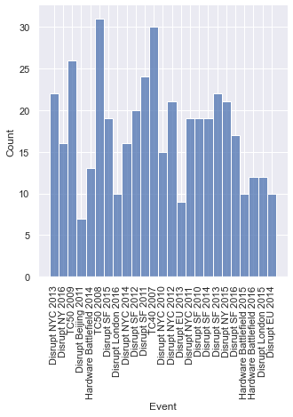

```python
# Plot the Distribution of Event variable
sns.displot(df_stup["Event"])
plt.xticks(rotation=90)
plt.show()
```

##### • Select only the Event that has disrupt keyword from 2013 onwards.

```python
# Displaying only the Event that has disrupt keyword from 2013 onwards
df_stup[(df_stup["Event"].str.contains("Disrupt")) & (df_stup["Event"].str[-4:].astype(int) >= 2013)]
```

|  | Startup | Product | Funding | Event | Result | OperatingState |
| --- | --- | --- | --- | --- | --- | --- |
| 1 | 3DLT | 3dlt.com | 630000 | Disrupt NYC 2013 | Contestant | Closed |
| 3 | 3Dprintler | 3dprintler.com | 1000000 | Disrupt NY 2016 | Audience choice | Operating |
| 13 | Agrilyst | agrilyst.com | 1000000 | Disrupt SF 2015 | Winner | Operating |
| 14 | Aiden | aiden.ai | 750000 | Disrupt London 2016 | Contestant | Operating |
| 16 | Aircall | aircall.io | 11600000 | Disrupt SF 2015 | Contestant | Operating |
| ... | ... | ... | ... | ... | ... | ... |
| 641 | Workspot | workspot.com | 15800000 | Disrupt NYC 2013 | Contestant | Operating |
| 642 | Xendo | xendo.com | 28000 | Disrupt SF 2014 | Contestant | Acquired |
| 646 | YayPay Inc | yaypay.com | 900000 | Disrupt London 2015 | Contestant | Operating |
| 656 | Zenefits | zenefits.com | 583600000 | Disrupt NYC 2013 | Finalist | Operating |
| 660 | Zula | zulaapp.com | 3400000 | Disrupt SF 2013 | Audience choice | Operating |

193 rows × 6 columns

##### • Write and perform your hypothesis along with significance test comparing the funds raised by companies across NY, SF and EU events from 2013 onwards.

###### Ho is μ(NY) = μ(SF) = μ(EU)

###### Ha is μ(NY) ≠ μ(SF) ≠ μ(EU)

###### Testing our Null Hypothesis against a 90% significance

```python
# Making a copy of Disrupt events of 2013 and onwards
df_disrupt_2013 = df_stup[(df_stup["Event"].str.contains("Disrupt")) & (df_stup["Event"].str[-4:].astype(int) >= 2013)].copy()

# Changing the Event column to more relevant classification for this question
df_disrupt_2013["Event"] = df_disrupt_2013["Event"].apply(lambda x: x.split(" ")[1])

# Printing pairwise_tukeyhsd output of the groups with alpha 0.1
print(pairwise_tukeyhsd(df_disrupt_2013["Funding"], df_disrupt_2013["Event"], alpha=0.1))
```

```
          Multiple Comparison of Means - Tukey HSD, FWER=0.10
=======================================================================
group1 group2    meandiff    p-adj      lower          upper     reject
-----------------------------------------------------------------------
    EU London    124668.4211    0.9 -32520747.9521 32770084.7942  False
    EU     NY   -972947.7952    0.9 -30392413.1308 28446517.5405  False
    EU    NYC  18544205.2368 0.5164 -10743628.7211 47832039.1948  False
    EU     SF    665681.4081    0.9 -26035586.1208 27366948.9369  False
London     NY  -1097616.2162    0.9 -29160495.4973 26965263.0649  False
London    NYC  18419536.8158  0.478  -9505317.1832 46344390.8147  False
London     SF     541012.987    0.9 -24657755.6448 25739781.6188  False
    NY    NYC   19517153.032 0.2657  -4557298.1833 43591604.2473  False
    NY     SF   1638629.2032    0.9 -19212262.1689 22489520.5754  False
   NYC     SF -17878523.8288 0.2061 -38543275.1781  2786227.5206  False
-----------------------------------------------------------------------
```

###### Based on the Advice from Tukey HSD test, we see that in every row the suggestion is that we should not reject the Null Hypothesis. Which follows that μ(NY) = μ(SF) = μ(EU).

###### Thus our conclusion is that the difference of mean in Funding, between NY, SF and EU Disrupt events 2013 onwards, is not Significant. Which might suggest that the investors are equally generous in Funding to EU, SF and NY regions for disrupt events, 2013 onwards.

##### • Plot the distribution plot comparing the 3 city events.

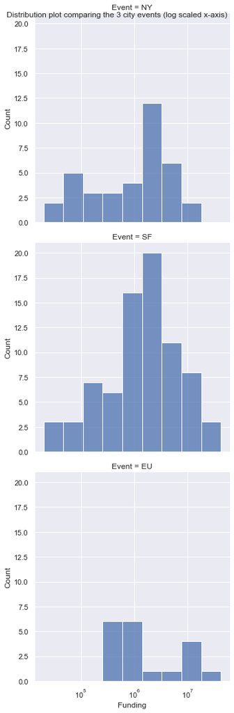

```python
# Displaying the Distribution plot as histogram comparing the 3 city events
sns.displot(x="Funding", row="Event", data=df_disrupt_2013[df_disrupt_2013["Event"].isin(["EU", "NY", "SF"])], log_scale=True)
plt.suptitle("Distribution plot comparing the 3 city events (log scaled x-axis)")
plt.show()
```

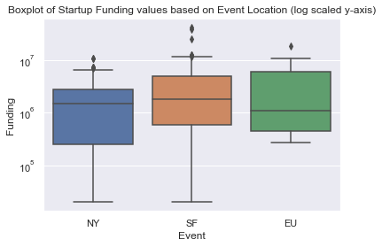

```python
# Displaying the Distribution plot as boxplot comparing the 3 city events
sns.boxplot(y="Funding", x="Event", data=df_disrupt_2013[df_disrupt_2013["Event"].isin(["EU", "NY", "SF"])])
plt.yscale("log")
plt.title("Boxplot of Startup Funding values based on Event Location (log scaled y-axis)")
plt.show()
```

#### 5. Write your observations on improvements or suggestions on quality, quantity, variety, velocity, veracity etc. on the data points collected to perform a better data analysis.

###### The data could be further classified into High, Medium and Low value Funding since the Variance in Funding values is pretty high. Further information on company inception date and close dates wherever applicable along with reason could be an interesting avenue to analyse since it would give a lot more understanding on the companies itself and hence would help investors understand where to spend their money.

###### Of course further information on the metadata would help understanding as well